# Extract vegetation phenology from MOD13A1 EVI

# 1 Example

Here, we illustrate how to use `phenofit` to extract vegetation phenology from MOD13A1 in the sampled points. Regional analysis also can be conducted in the similar way.

## 1.1 1.1 Initial weights for input data

Load packages.

Set global parameters for `phenofit`

```r
# lambda   <- 5    # non-parameter Whittaker, only suit for 16-day. Other time-scale
# should assign a lambda.
ymax_min   <- 0.1  # the maximum ymax shoud be greater than `ymax_min`
rymin_less <- 0.8  # trough < ymin + A*rymin_less
nptperyear <- 23   # How many points for a single year
wFUN       <- wBisquare #wTSM #wBisquare # Weights updating function, could be one of `wTSM`, 'wBisquare', `wChen` and `wSELF`.
```

- Add date according to composite day of the year (DayOfYear), other than image date.
- Add weights according to `SummaryQA`.

For MOD13A1, Weights can by initialed by `SummaryQA` band (also suit for MOD13A2 and MOD13Q1). There is already a `QC` function for `SummaryQA`, i.e. `qc_summary`.

| SummaryQA | Pixel reliability summary QA | weight |
| --- | --- | --- |
| -1 Fill/No data | Not processed | `wmin` |
| 0 Good data | Use with confidence | 1 |
| 1 Marginal data | Useful but look at detailed QA for more information | 0.5 |
| 2 Snow/ice | Pixel covered with snow/ice | `wmin` |
| 3 Cloudy | Pixel is cloudy | `wmin` |

```r
data('MOD13A1')
df <- MOD13A1$dt
st <- MOD13A1$st

df[, `:=`(date = ymd(date), year = year(date), doy = as.integer(yday(date)))]
df[is.na(DayOfYear), DayOfYear := doy] # If DayOfYear is missing

# In case of last scene of a year, doy of last scene could in the next year
df[abs(DayOfYear - doy) >= 300, t := as.Date(sprintf("%d-%03d", year+1, DayOfYear), "%Y-%j")] # last scene
df[abs(DayOfYear - doy) <  300, t := as.Date(sprintf("%d-%03d", year  , DayOfYear), "%Y-%j")]

df <- df[!duplicated(df[, .(site, t)]), ]
# # MCD12Q1.006 land cover 1-17, IGBP scheme
# IGBPnames_006 <- c("ENF", "EBF", "DNF", "DBF", "MF" , "CSH",
#               "OSH", "WSA", "SAV", "GRA", "WET", "CRO",
#               "URB", "CNV", "SNOW", "BSV", "water", "UNC")
# Initial weights
df[, c("QC_flag", "w") := qc_summary(SummaryQA)]
df <- df[, .(site, y = EVI/1e4, t, date, w, QC_flag)]
```

## 1.2 2.1 load site data

```r
sites        <- unique(df$site)
sitename     <- sites[3]
d            <- df[site == sitename] # get the first site data
sp           <- st[site == sitename]

south      <- sp$lat < 0
print      <- FALSE # whether print progress
IsPlot     <- TRUE  # for brks

prefix_fig <- "phenofit"
titlestr   <- with(sp, sprintf('[%03d,%s] %s, lat = %5.2f, lon = %6.2f',
                                     ID, site, IGBPname, lat, lon))
file_pdf   <- sprintf('Figure/%s_[%03d]_%s.pdf', prefix_fig, sp$ID[1], sp$site[1])
```

If need night temperature (Tn) to constrain ungrowing season backgroud value, NA values in Tn should be filled.

```r
d$Tn %<>% zoo::na.approx(maxgap = 4)
plot(d$Tn, type = "l"); abline(a = 5, b = 0, col = "red")
```

[output not shown]

## 1.3 2.2 Check input data

```r
dnew  <- add_HeadTail(d, south, nptperyear = 23) # add additional one year in head and tail
INPUT <- check_input(dnew$t, dnew$y, dnew$w, dnew$QC_flag,
                     nptperyear, south,
                     maxgap = nptperyear/4, alpha = 0.02, wmin = 0.2)
```

## 1.4 2.3 Divide growing seasons

Simply treating calendar year as a complete growing season will induce a considerable error for phenology extraction. A simple growing season dividing method was proposed in `phenofit`.

The growing season dividing method rely on heavily in Whittaker smoother.

Procedures of initial weight, growing season dividing, curve fitting, and phenology extraction are conducted separately.

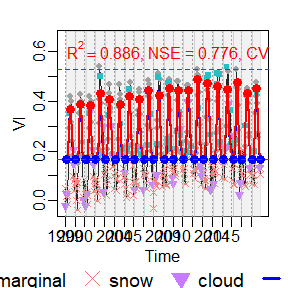

```r
par(mar = c(3, 2, 2, 1), mgp = c(3, 0.6, 0))
lambda <- init_lambda(INPUT$y)
# The detailed information of those parameters can be seen in `season`.
# brks   <- season(INPUT, nptperyear,
#                FUN = smooth_wWHIT, wFUN = wFUN, iters = 2,
#                lambda = lambda,
#                IsPlot = IsPlot, plotdat = d,
#                south = d$lat[1] < 0,
#                rymin_less = 0.6, ymax_min = ymax_min,
#                max_MaxPeaksperyear =2.5, max_MinPeaksperyear = 3.5) #, ...
# get growing season breaks in a 3-year moving window
brks2 <- season_mov(INPUT,
    list(rFUN = "smooth_wWHIT", wFUN = wFUN, maxExtendMonth = 6, r_min = 0.1))
plot_season(INPUT, brks2)
```

## 1.5 2.4 Curve fitting

```r
fit  <- curvefits(INPUT, brks2,
    options = list(
        methods = c("AG", "Zhang", "Beck", "Elmore"), #,"klos",, 'Gu'
        wFUN = wFUN,
        nextend = 2, maxExtendMonth = 3, minExtendMonth = 1, minPercValid = 0.2
    ))

## check the curve fitting parameters
l_param <- get_param(fit)
print(str(l_param, 1))
```

```
## List of 4
##  $ AG    : tibble [20 × 8] (S3: tbl_df/tbl/data.frame)
##  $ Zhang : tibble [20 × 8] (S3: tbl_df/tbl/data.frame)
##  $ Beck  : tibble [20 × 7] (S3: tbl_df/tbl/data.frame)
##  $ Elmore: tibble [20 × 8] (S3: tbl_df/tbl/data.frame)
## NULL
```

```r
print(l_param$AG)
```

```
## # A tibble: 20 × 8
##    flag      t0    mn    mx    rsp    a3    rau    a5
##    <chr>  <dbl> <dbl> <dbl>  <dbl> <dbl>  <dbl> <dbl>
##  1 1999_1 -167. 0.169 0.399 0.0195  4.34 0.0175  6
##  2 2000_1  202. 0.168 0.407 0.0320  3.56 0.0152  5.79
##  3 2001_1  564. 0.168 0.402 0.0204  3.92 0.0169  6
##  4 2002_1  934. 0.168 0.530 0.0327  2    0.0156  2
##  5 2003_1 1275. 0.167 0.433 0.0268  2    0.0124  3.64
##  6 2004_1 1689. 0.169 0.445 0.0166  5.09 0.0372  2
##  7 2005_1 2025. 0.172 0.450 0.0223  6    0.0162  3.62
##  8 2006_1 2370. 0.166 0.420 0.0280  2.01 0.0112  3.07
##  9 2007_1 2751. 0.166 0.482 0.0213  2    0.0148  2.94
## 10 2008_1 3153. 0.170 0.481 0.0132  5.09 0.0301  6
## 11 2009_1 3523. 0.168 0.479 0.0141  6    0.0282  2
## 12 2010_1 3840. 0.168 0.488 0.0231  2    0.0129  2
## 13 2011_1 4209. 0.175 0.468 0.0283  2    0.0135  4.92
## 14 2012_1 4586. 0.166 0.523 0.0201  4.61 0.0156  2
## 15 2013_1 4966. 0.166 0.482 0.0140  6    0.0178  2.05
## 16 2014_1 5306. 0.169 0.507 0.0281  2    0.0127  2.70
## 17 2015_1 5700. 0.183 0.485 0.0146  5.40 0.0277  2
## 18 2016_1 6024. 0.175 0.487 0.0363  2    0.0124  4.38
## 19 2017_1 6405. 0.169 0.448 0.0204  5.94 0.0128  3.63
## 20 2018_1 6789. 0.165 0.450 0.0121  4.11 0.0208  2
```

```r
d_fit <- get_fitting(fit)
```

[output not shown]

```r
## Get GOF information
d_gof <- get_GOF(fit)
# fit$stat <- stat
print(head(d_gof))
```

```
##      flag   meth        R2       NSE         R       RMSE       pvalue n_sim
##    <char> <char>     <num>     <num>     <num>      <num>        <num> <num>
## 1: 1999_1     AG 0.8233472 0.6145234 0.9073848 0.08520015 2.337043e-09    23
## 2: 1999_1  Zhang 0.8282894 0.6183996 0.9101041 0.08477070 1.730224e-09    23
## 3: 1999_1   Beck 0.8286265 0.6186920 0.9102893 0.08473822 1.694577e-09    23
## 4: 1999_1 Elmore 0.8334801 0.6051443 0.9129513 0.08623043 1.249992e-09    23
## 5: 2000_1     AG 0.8189371 0.5535112 0.9049514 0.09770633 7.301264e-09    22
## 6: 2000_1  Zhang 0.8263049 0.5556140 0.9090131 0.09747597 4.799998e-09    22
```

```r
# print(fit$fits$AG$`2002_1`$ws)
print(fit$`2002_1`$fFIT$AG$ws)
```

[output not shown]

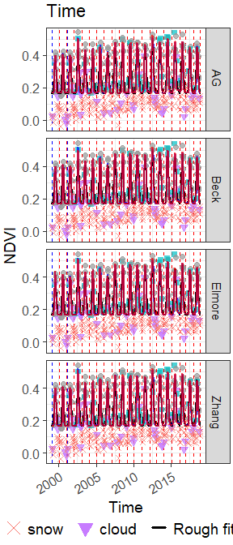

```r
## visualization
g <- plot_curvefits(d_fit, brks2, NULL, ylab = "NDVI", "Time",
                   theme = coord_cartesian(xlim = c(ymd("2000-04-01"), ymd("2017-07-31"))))
grid::grid.newpage(); grid::grid.draw(g)# plot to check the curve fitting
```

```r
# write_fig(g, "Figure1_phenofit_curve_fitting.pdf", 10, 6)
```

## 1.6 2.5 Extract phenology

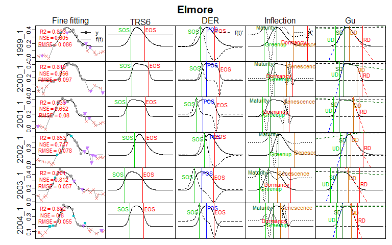

```r
# pheno: list(p_date, p_doy)
l_pheno <- get_pheno(fit, IsPlot = F) #%>% map(~melt_list(., "meth"))

# ratio = 1.15
# file <- "Figure5_Phenology_Extraction_temp.pdf"
# cairo_pdf(file, 8*ratio, 6*ratio)
# temp <- get_pheno(fit$fits$ELMORE[2:6], IsPlot = T)
# dev.off()
# file.show(file)

## check the extracted phenology
pheno <- get_pheno(fit[1:6], "Elmore", IsPlot = T)
```

```r
# print(str(pheno, 1))
head(l_pheno$doy$AG)
```

```
##      flag     origin TRS2.sos TRS2.eos TRS5.sos TRS5.eos TRS6.sos TRS6.eos
##    <char>     <Date>    <num>    <num>    <num>    <num>    <num>    <num>
## 1: 1999_1 1999-01-01      142      261      152      253      155      250
## 2: 2000_1 2000-01-01      167      275      175      264      177      261
## 3: 2001_1 2001-01-01      143      263      154      255      157      252
## 4: 2002_1 2002-01-01      165      286      178      258      182      250
## 5: 2003_1 2003-01-01      132      271      149      253      153      247
## 6: 2004_1 2004-01-01      162      264      173      252      176      248
##    DER.sos DER.pos DER.eos    UD    SD    DD    RD Greenup Maturity Senescence
##      <num>   <num>   <num> <num> <num> <num> <num>   <num>    <num>      <num>
## 1:     151     199     254   136   168   239   267     129      175        235
## 2:     174     203     266   163   186   249   281     156      193        243
## 3:     153     199     256   138   171   241   269     130      179        236
## 4:     182     204     249   161   196   222   295     153      204        220
## 5:     153     180     254   127   171   227   282     118      180        197
## 6:     171     229     248   157   189   235   268     150      196        274
##    Dormancy
##       <num>
## 1:      272
## 2:      287
## 3:      275
## 4:      310
## 5:      294
## 6:      375
```